# writeup

Kelly Chen

10/2/2021

## Introduction

The world series is a best-of-7 match-up between the champions of the American and National Leagues of Major League Baseball. In this assignment, you are going to explain probability calculations related to the world series.

Suppose that the Braves and the Yankees are teams competing in the World Series.

The table below has the two possible schedules for each game of the series. (NYC = New York City, ATL = Atlanta)

| Overall advantage | Game 1 | Game 2 | Game 3 | Game 4 | Game 5 | Game 6 | Game 7 |
| --- | --- | --- | --- | --- | --- | --- | --- |
| Braves | ATL | ATL | NYC | NYC | NYC | ATL | ATL |
| Yankees | NYC | NYC | ATL | ATL | ATL | NYC | NYC |

Let PB be the probability that the Braves win a single head-to-head match-up with the Yankees, under the assumption that home field advantage doesn’t exist. Let PBH denote the probability that the Braves win a single head-to-head match-up with the Yankees as the home team (H for home). Let PBA denote the probability that the Braves win a single head-to-head match-up with the away team (A for away).

| Gamelocation | No advantage | Advantage |
| --- | --- | --- |
| ATL | PB | PBH = PB * 1.1 |
| NYC | PB | PBA = 1 − (1 − PB) * 1.1 |

## Initial Setup and Variable definition

This is the initial set up for the analysis. Based on the above information, we can set the variables to prepare for later analysis.

```r
require(dplyr)
require(data.table)
# Get all possible outcomes
apo <- fread("all-possible-world-series-outcomes.csv")

# Home field indicator
hfi <- c(1,1,0,0,0,1,1) #{ATL, ATL, NYC, NYC, NYC, ATL, ATL}

# P_B
pb <- 0.55
advantage_multiplier <- 1.1 # Set = 1 for no advantage
pbh <- pb*advantage_multiplier
pba <- 1 - (1 - pb)*advantage_multiplier
```

Using analysis method, we can calculate the probability of each possible outcome and take the average win rate for the given sequence.

```r
# Calculate the probability of each possible outcome
apo[, p := NA_real_] # Initialize new column in apo to store prob
for(i in 1:nrow(apo)){
  prob_game <- rep(1, 7)
  for(j in 1:7){
    p_win <- ifelse(hfi[j], pbh, pba)
    prob_game[j] <- case_when(
        apo[i,j,with=FALSE] == "W" ~ p_win
      , apo[i,j,with=FALSE] == "L" ~ 1 - p_win
      , TRUE ~ 1
    )
  }
  apo[i, p := prod(prob_game)] # Data.table syntax
}

# Sanity check: does sum(p) == 1?
#apo[, sum(p)] # This is data.table notation

# Probability of overall World Series outcomes
apo[, sum(p), overall_outcome]
```

```
##    overall_outcome        V1
## 1:               W 0.6345261
## 2:               L 0.3654739
```

## Question 1:

Probability that the Braves win the world series when the sequence of game locations is {NYC, NYC, ATL, ATL, ATL, NYC, NYC}

**With Home field advantage**:

```r
# Home field indicator
alter_loca <- c(0,0,1,1,1,0,0)

# Calculate the probability of each possible outcome
apo[, p := NA_real_] # Initialize new column in apo to store prob
for(i in 1:nrow(apo)){
  prob_game <- rep(1, 7)
  for(j in 1:7){
    p_win <- ifelse(alter_loca[j], pbh, pba)
    prob_game[j] <- case_when(
        apo[i,j,with=FALSE] == "W" ~ p_win
      , apo[i,j,with=FALSE] == "L" ~ 1 - p_win
      , TRUE ~ 1
    )
  }
  apo[i, p := prod(prob_game)] # Data.table syntax
}

# Probability of overall World Series outcomes
win_with<-apo[, sum(p), overall_outcome]
win_home<-win_with$V1[1]
win_home
```

```
## [1] 0.604221
```

If the Braves win the world series when the sequence of game locations is {NYC, NYC, ATL, ATL, ATL, NYC, NYC}, the winning probability of Braves win the world series would be 0.604.

**Situation without home field advantage**:

```r
#Win probability in world series of Braves without home field advantage, which means every single game the win probability is the same

(win_without<-1-pbinom(3,7,0.55))
```

```
## [1] 0.6082878
```

Win probability in world series of Braves without home field advantage, which means every single game the win probability is the same when there is no home field advantage, the winning probability is 0.608 in this situation.

**The difference of two probabilities**:

```r
win_home-win_without
```

```
## [1] -0.004066825
```

This is the difference of winning probabilities between with home field advantage and without home field advantage. We can see that with home field advantage existing, the winrate of Braves would be less than without home field advantage. This is because more game are played away home field in the world series.

## Question2

**Situation with home field advantage using simulation**:

We randomly simulate the result of the 7 matches, and simulated 10000 times for the model to calculate the winrate.

```r
#Randomly simulate the result of the 7 matches

set.seed(100)
#create matrix for the new simulation
n<-10000
po<-matrix(rep(NA,n*8),ncol=8,byrow = TRUE)
colnames(po)<-c('Game 1','Game 2','Game 3','Game 4','Game 5','Game 6','Game 7','Outcome')

#Simulation
test_seq<-seq(1,n)

for (i in test_seq){
  match_outcome<-rep(1,7)
  for (j in 1:7){
    match_outcome[j]<-rbinom(1,1,ifelse(alter_loca[j],pbh,pba))
  }
  po[i,1:7]<- match_outcome
  po[i,8]<-round(mean(match_outcome))
}
(sim_home<-mean(po[,'Outcome']))
```

```
## [1] 0.6047
```

Using simulation, we can see that the winning probability of Braves is 0.6047 when there is home field advantage.

**Situation without home field advantage using simulation**:

```r
set.seed(100)
n<-10000
po<-matrix(rep(NA,n*8),ncol=8,byrow = TRUE)
colnames(po)<-c('Game 1','Game 2','Game 3','Game 4','Game 5','Game 6','Game 7','Outcome')


#Simulation
test_seq<-seq(1,n)

for (i in test_seq){

  match_outcome<-rbinom(7,1,pb)
  po[i,1:7]<- match_outcome
  po[i,8]<-round(mean(match_outcome))
}
(sim_no_home<-mean(po[,'Outcome']))
```

```
## [1] 0.6085
```

When running the simulation of without home field advantage, also take the average of 10000 times of simulation, the winning probability without home field advantage is 0.6085.

**Difference of the two simulation**

```r
(diff_sim<-abs(sim_home-sim_no_home))
```

```
## [1] 0.0038
```

The difference of the winning probability in simulation of with/without home field advantage is 0.0038 when applying set.seed(100) to keep the simulation result consistant.

## Question 3

**Relative Error**

Formula for relative error:|Measured value-true value|/True value

```r
#Relative Error of having home field advantage
abs(sim_home-win_home)/win_home
```

```
## [1] 0.0007928033
```

```r
#relative error of without home field advantage
abs(sim_no_home-win_without)/win_without
```

```
## [1] 0.0003488532
```

**Absolute Error**

Formula for absolute error: |Measured value-true value|

```r
#absolute error of having home field advantage
abs(sim_home-win_home)
```

```
## [1] 0.0004790284
```

```r
#absolute error of without home field advantage
abs(sim_no_home-win_without)
```

```
## [1] 0.0002122031
```

## Question 4

**Situation with home field advantage**:

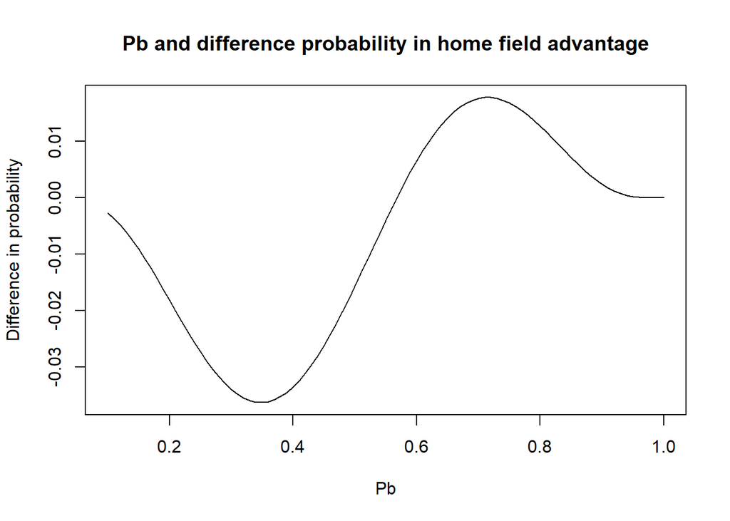

```r
sim_pb<-seq(0.1,1,0.01)
new_prob<-rep(NA,length(sim_pb))
without_win<-rep(NA,length(sim_pb))
total_diff<-rep(NA,length(sim_pb))

for (x in seq_along(sim_pb)){
  pbh_new <- sim_pb[x]*advantage_multiplier
  pba_new <- 1 - (1 - sim_pb[x])*advantage_multiplier
  # Calculate the probability of each possible outcome
  apo[, p := NA_real_] # Initialize new column in apo to store prob
  for(i in 1:nrow(apo)){
    prob_game <- rep(1, 7)
    for(j in 1:7){
      p_win <- ifelse(alter_loca[j], pbh_new, pba_new)
      prob_game[j] <- case_when(
          apo[i,j,with=FALSE] == "W" ~ p_win
        , apo[i,j,with=FALSE] == "L" ~ 1 - p_win
        , TRUE ~ 1
      )
    }
  apo[i, p := prod(prob_game)] # Data.table syntax

  # Probability of overall World Series outcomes
  win_with<-apo[, sum(p), overall_outcome]
  new_prob[x]<-win_with$V1[1]
  without_win[x]<- 1-pbinom(3,7,sim_pb[x])
  total_diff[x]<-(new_prob[x]-without_win[x])
  }
}

# Make Plot between Pb and probability of winning the world series

plot(sim_pb,total_diff,type='l',xlab='Pb',ylab='Difference in probability',main='Pb and difference probability in home field advantage')
```

## Question 5

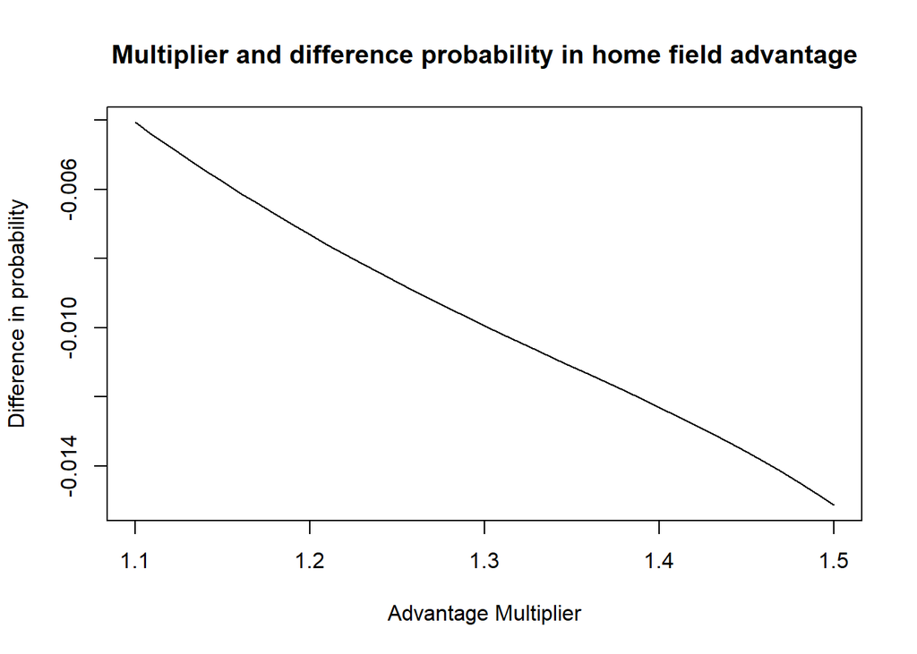

```r
#Set up sequence on advantage multiploer to be number between 1.1 to 1.5, every break is 0.01.

advantage_multiplier_new<-seq(1.1,1.5,0.01)
new_prob<-rep(NA,length(advantage_multiplier_new))
without_win<-rep(NA,length(advantage_multiplier_new))
total_diff<-rep(NA,length(advantage_multiplier_new))

#Simulation
for (q in seq_along(advantage_multiplier_new)){
  pbh_new <- pb*(advantage_multiplier_new[q])
  pba_new <- 1 - (1 - pb)*advantage_multiplier_new[q]
  # Calculate the probability of each possible outcome
  apo[, p := NA_real_] # Initialize new column in apo to store prob
  for(i in 1:nrow(apo)){
    prob_game <- rep(1, 7)
    for(j in 1:7){
      p_win <- ifelse(alter_loca[j], pbh_new, pba_new)
      prob_game[j] <- case_when(
          apo[i,j,with=FALSE] == "W" ~ p_win
        , apo[i,j,with=FALSE] == "L" ~ 1 - p_win
        , TRUE ~ 1
      )
    }
  apo[i, p := prod(prob_game)] # Data.table syntax

  # Probability of overall World Series outcomes
  win_with<-apo[, sum(p), overall_outcome]
  new_prob[q]<-win_with$V1[1]

  total_diff[q]<-(new_prob[q]-win_without)
  }
}
# Make Plot between Advantage multiplier and probability of winning the world series

plot(advantage_multiplier_new,total_diff,type='l',xlab='Advantage Multiplier',ylab='Difference in probability',main='Multiplier and difference probability in home field advantage')
```

Answer: There is a relationship between advantage multiplier and the difference of winning probabilities with/without home field advantage. Since most of the matches are away from home, the larger the multiplier means the larger the weight of home field advantage, leading to negative relationship of the difference.